# Activity Monitoring

```r
knitr::opts_chunk$set(echo = TRUE)
```

## Load library

```r
library(ggplot2)
library(dplyr)
```

## Reading dataset and process the data

```r
setwd("C:/Users/wenju/OneDrive/Documents/R/repoducible_research/week2")
activity <- read.csv("activity.csv",header =TRUE)
activity$date <- as.Date(activity$date, "%Y-%m-%d")
str(activity)
```

```
## 'data.frame':    17568 obs. of  3 variables:
##  $ steps   : int  NA NA NA NA NA NA NA NA NA NA ...
##  $ date    : Date, format: "2012-10-01" "2012-10-01" ...
##  $ interval: int  0 5 10 15 20 25 30 35 40 45 ...
```

## Histogram of the total number of steps taken each day

### 1. Calculating the total number of steps taken per day (ignore the missing valuve in the dataset)

```r
day_step<- with(activity, tapply(steps, date, sum, na.rm = TRUE))
day_step
```

```
## 2012-10-01 2012-10-02 2012-10-03 2012-10-04 2012-10-05 2012-10-06 2012-10-07
##          0        126      11352      12116      13294      15420      11015
## 2012-10-08 2012-10-09 2012-10-10 2012-10-11 2012-10-12 2012-10-13 2012-10-14
##          0      12811       9900      10304      17382      12426      15098
## 2012-10-15 2012-10-16 2012-10-17 2012-10-18 2012-10-19 2012-10-20 2012-10-21
##      10139      15084      13452      10056      11829      10395       8821
## 2012-10-22 2012-10-23 2012-10-24 2012-10-25 2012-10-26 2012-10-27 2012-10-28
##      13460       8918       8355       2492       6778      10119      11458
## 2012-10-29 2012-10-30 2012-10-31 2012-11-01 2012-11-02 2012-11-03 2012-11-04
##       5018       9819      15414          0      10600      10571          0
## 2012-11-05 2012-11-06 2012-11-07 2012-11-08 2012-11-09 2012-11-10 2012-11-11
##      10439       8334      12883       3219          0          0      12608
## 2012-11-12 2012-11-13 2012-11-14 2012-11-15 2012-11-16 2012-11-17 2012-11-18
##      10765       7336          0         41       5441      14339      15110
## 2012-11-19 2012-11-20 2012-11-21 2012-11-22 2012-11-23 2012-11-24 2012-11-25
##       8841       4472      12787      20427      21194      14478      11834
## 2012-11-26 2012-11-27 2012-11-28 2012-11-29 2012-11-30
##      11162      13646      10183       7047          0
```

### 2. Making a histogram of the total number of steps taken each day

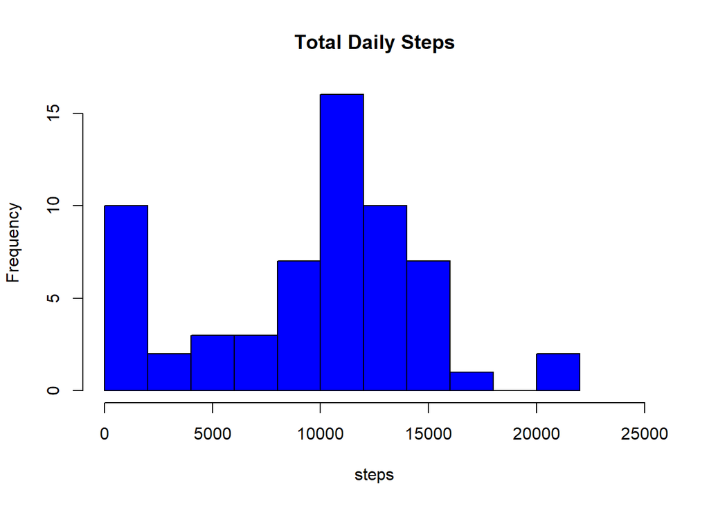

```r
hist(day_step, main = "Total Daily Steps", xlab= "steps",
     col = "blue", breaks = 10, xlim = c(0, 25000))
```

```r
dev.copy(png, "plot1.png",
         width=720, height=720)
```

```r
dev.off()
```

## Mean and median of the total number steps taken per day

```r
day_mean <- mean(day_step)
print(paste("mean of the total steps per day: ", day_mean))
```

```
## [1] "mean of the total steps per day:  9354.22950819672"
```

```r
day_median <- median(day_step)
print(paste("median of the total steps per day: ", day_median))
```

```
## [1] "median of the total steps per day:  10395"
```

## Time series plot of the average number of steps taken

### 1. Calculating the average number of steps taken per 5-minute inteval

```r
intv_step<- with(activity, tapply(steps, interval, mean, na.rm = TRUE))
intestep <- data.frame(interval= as.numeric(names(intv_step)),
                       steps = intv_step)
str(intestep)
```

```
## 'data.frame':    288 obs. of  2 variables:
##  $ interval: num  0 5 10 15 20 25 30 35 40 45 ...
##  $ steps   : num  1.717 0.3396 0.1321 0.1509 0.0755 ...
```

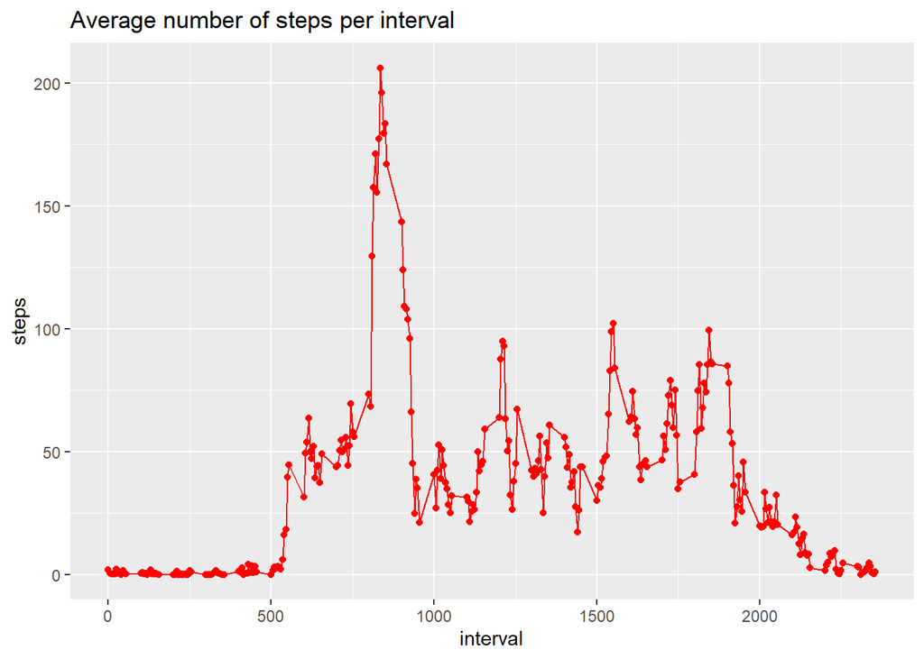

```r
inteplot<- ggplot(data= intestep, aes(x=interval, y=steps)) +
    geom_line(color= "red") + geom_point(color = "red")+
    ggtitle("Average number of steps per interval")
inteplot
```

```r
dev.copy(png, "plot2.png",
         width=720, height=720)
```

```r
dev.off()
```

## Calculateing which 5-minute interval that, on average, contains the maximum number of steps

```r
max_intevel<- filter(intestep, intestep$steps == max(intestep$steps))
maxinterval <-max_intevel$interval
print(paste("The 5-minute interval, on average, conatins the maximum number of steps is: ", maxinterval))
```

```
## [1] "The 5-minute interval, on average, conatins the maximum number of steps is:  835"
```

## Code to describe and show a strategy for imputing missing data

### 1. Calculating and reporting the total number of missing values in the dataset

[output not shown]

### 2. Devising a strategy for filling in all of the missing values in the dataset. Creating a new dataset in which the missing value are replaced by the the mean for that 5-minute interval.

2.1 method 1

```r
activity2 <- activity
for (i in 1 :nrow(activity2)){
    if (is.na(activity2$steps[i])) {
        inter<- activity2$interval[i]
        subact<- subset(activity2, interval == inter)
        imean <- mean(subact$steps, na.rm = TRUE)
        activity2$steps[i]<- imean
    }
}
head(activity2)
```

```
##       steps       date interval
## 1 1.7169811 2012-10-01        0
## 2 0.3396226 2012-10-01        5
## 3 0.1320755 2012-10-01       10
## 4 0.1509434 2012-10-01       15
## 5 0.0754717 2012-10-01       20
## 6 2.0943396 2012-10-01       25
```

```r
table(is.na(activity2$steps))
```

```
##
## FALSE
## 17568
```

2.2 method 2

```r
activity3 <- activity %>% group_by(interval) %>%
    mutate(step_mean = mean(steps,na.rm=TRUE))

for (i in 1 :nrow(activity3)){
    if (is.na(activity3$steps[i])){
    activity3$steps[i]<- activity3$step_mean[i]
    }
}
activity3<- activity3%>% select(1:3)
head(activity3)
```

```
## # A tibble: 6 x 3
## # Groups:   interval [6]
##    steps date       interval
##    <dbl> <date>        <int>
## 1 1.72   2012-10-01        0
## 2 0.340  2012-10-01        5
## 3 0.132  2012-10-01       10
## 4 0.151  2012-10-01       15
## 5 0.0755 2012-10-01       20
## 6 2.09   2012-10-01       25
```

## Histogram of the total number of steps taken each day after missing values are imputed.

### 1. Calculating the total number of steps taken per day after missing values are imputed.

```r
day_step2<- with(activity2, tapply(steps, date, sum))
```

### 2. Making a histogram of the total number of steps taken each day after missing values are imputed.

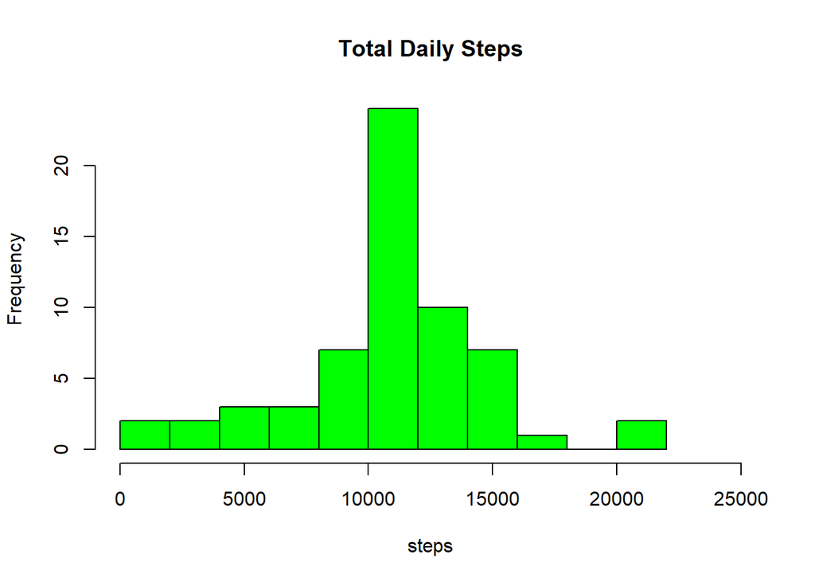

```r
hist(day_step2, main = "Total Daily Steps", xlab= "steps",
     col = "green", breaks = 10, xlim = c(0, 25000))
```

```r
dev.copy(png, "plot3.png",
         width=720, height=720)
```

```r
dev.off()
```

## Panel plot comparing the average number of steps taken per 5-minute interval across weekdays and weekends.

### 1. Defining the weekday and weekend and adding a column to indicate it is weekday or wenkend

```r
wkds <- c('Monday', 'Tuesday', 'Wednesday', 'Thursday', 'Friday')
activity2$wDay <- factor((weekdays(activity$date) %in% wkds),
                   levels=c(FALSE, TRUE),
                   labels=c('weekend', 'weekday'))
head(activity2)
```

```
##       steps       date interval    wDay
## 1 1.7169811 2012-10-01        0 weekday
## 2 0.3396226 2012-10-01        5 weekday
## 3 0.1320755 2012-10-01       10 weekday
## 4 0.1509434 2012-10-01       15 weekday
## 5 0.0754717 2012-10-01       20 weekday
## 6 2.0943396 2012-10-01       25 weekday
```

### 2. Calulating the average number of steps taken per 5-minute interval after missing value are imputed, average aross all weekday or weeken days.

```r
act2 <- activity2 %>%
    group_by(interval, wDay) %>%
    summarise(stepmean=mean(steps))
head(act2)
```

```
## # A tibble: 6 x 3
## # Groups:   interval [3]
##   interval wDay    stepmean
##      <int> <fct>      <dbl>
## 1        0 weekend   0.215
## 2        0 weekday   2.25
## 3        5 weekend   0.0425
## 4        5 weekday   0.445
## 5       10 weekend   0.0165
## 6       10 weekday   0.173
```

### 3. Making a Panle plots

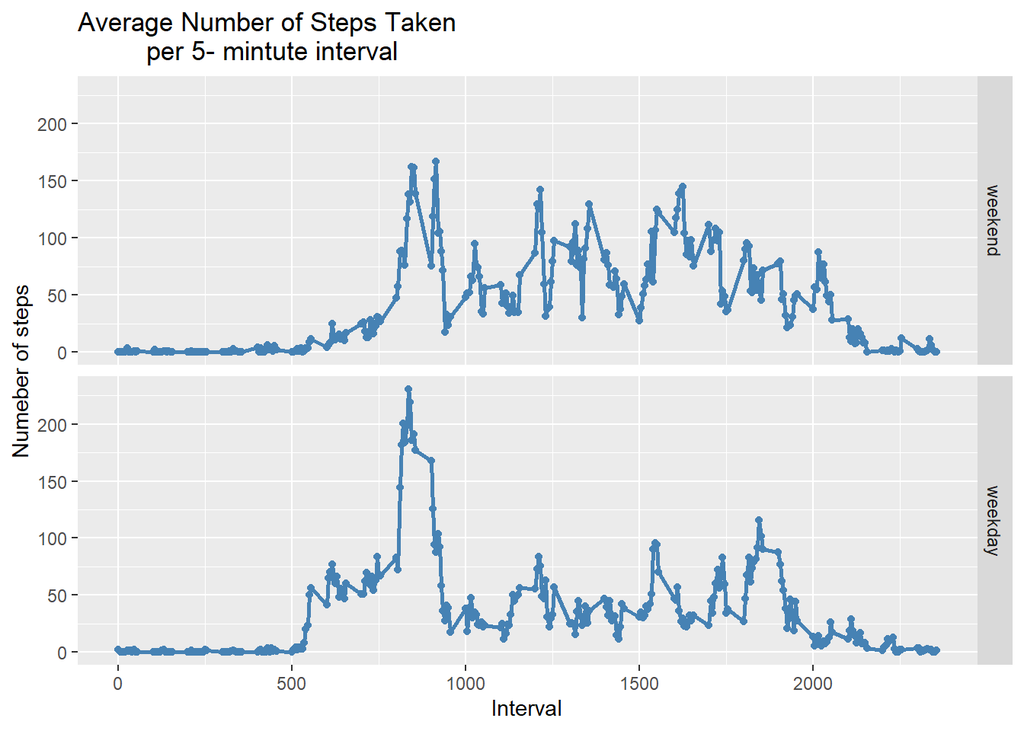

```r
p<-ggplot(data = act2, aes(interval, stepmean)) +
    geom_line(color = "steelblue", size = 1) +
    geom_point(color = "steelblue") +
    labs(title = "Average Number of Steps Taken
         per 5- mintute interval",
         y = "Numeber of steps", x = "Interval") +
facet_grid(wDay ~ .)
p
```

```r
dev.copy(png, "plot4.png",
         width=720, height=720)
```

```r
dev.off()
```